# Risk Factor Analysis

## Outcome Variable

**Outcome Variable:** wast_rec90d

## Predictor Variables

**Intervention Variable:** fage

**Adjustment Set:**

- arm
- W_mage
- meducyrs
- feducyrs
- W_mhtcm
- W_mwtkg
- W_mbmi
- W_fhtcm
- single
- brthmon
- delta_W_mage
- delta_meducyrs
- delta_feducyrs
- delta_W_mhtcm
- delta_W_mwtkg
- delta_W_mbmi
- delta_W_fhtcm
- delta_single
- delta_brthmon

## Stratifying Variables

The analysis was stratified on these variable(s):

- agecat
- studyid
- country

## Data Summary

| agecat | studyid | country | fage | wast_rec90d | n_cell | n |
| --- | --- | --- | --- | --- | --- | --- |
| 0-24 months | ki0047075b-MAL-ED | BANGLADESH | >=38 | 0 | 12 | 76 |
| 0-24 months | ki0047075b-MAL-ED | BANGLADESH | >=38 | 1 | 22 | 76 |
| 0-24 months | ki0047075b-MAL-ED | BANGLADESH | <32 | 0 | 5 | 76 |
| 0-24 months | ki0047075b-MAL-ED | BANGLADESH | <32 | 1 | 16 | 76 |
| 0-24 months | ki0047075b-MAL-ED | BANGLADESH | [32-38) | 0 | 11 | 76 |
| 0-24 months | ki0047075b-MAL-ED | BANGLADESH | [32-38) | 1 | 10 | 76 |
| 0-24 months | ki0047075b-MAL-ED | BRAZIL | >=38 | 0 | 0 | 6 |
| 0-24 months | ki0047075b-MAL-ED | BRAZIL | >=38 | 1 | 0 | 6 |
| 0-24 months | ki0047075b-MAL-ED | BRAZIL | <32 | 0 | 0 | 6 |
| 0-24 months | ki0047075b-MAL-ED | BRAZIL | <32 | 1 | 2 | 6 |
| 0-24 months | ki0047075b-MAL-ED | BRAZIL | [32-38) | 0 | 2 | 6 |
| 0-24 months | ki0047075b-MAL-ED | BRAZIL | [32-38) | 1 | 2 | 6 |
| 0-24 months | ki0047075b-MAL-ED | INDIA | >=38 | 0 | 6 | 122 |
| 0-24 months | ki0047075b-MAL-ED | INDIA | >=38 | 1 | 9 | 122 |
| 0-24 months | ki0047075b-MAL-ED | INDIA | <32 | 0 | 24 | 122 |
| 0-24 months | ki0047075b-MAL-ED | INDIA | <32 | 1 | 27 | 122 |
| 0-24 months | ki0047075b-MAL-ED | INDIA | [32-38) | 0 | 17 | 122 |
| 0-24 months | ki0047075b-MAL-ED | INDIA | [32-38) | 1 | 39 | 122 |
| 0-24 months | ki0047075b-MAL-ED | NEPAL | >=38 | 0 | 1 | 32 |
| 0-24 months | ki0047075b-MAL-ED | NEPAL | >=38 | 1 | 5 | 32 |
| 0-24 months | ki0047075b-MAL-ED | NEPAL | <32 | 0 | 2 | 32 |
| 0-24 months | ki0047075b-MAL-ED | NEPAL | <32 | 1 | 7 | 32 |
| 0-24 months | ki0047075b-MAL-ED | NEPAL | [32-38) | 0 | 1 | 32 |
| 0-24 months | ki0047075b-MAL-ED | NEPAL | [32-38) | 1 | 16 | 32 |
| 0-24 months | ki0047075b-MAL-ED | PERU | >=38 | 0 | 0 | 10 |
| 0-24 months | ki0047075b-MAL-ED | PERU | >=38 | 1 | 1 | 10 |
| 0-24 months | ki0047075b-MAL-ED | PERU | <32 | 0 | 1 | 10 |
| 0-24 months | ki0047075b-MAL-ED | PERU | <32 | 1 | 4 | 10 |
| 0-24 months | ki0047075b-MAL-ED | PERU | [32-38) | 0 | 1 | 10 |
| 0-24 months | ki0047075b-MAL-ED | PERU | [32-38) | 1 | 3 | 10 |

[output cut: 204 more lines]

The following strata were considered:

- agecat: 0-24 months, studyid: ki0047075b-MAL-ED, country: BANGLADESH
- agecat: 0-24 months, studyid: ki0047075b-MAL-ED, country: BRAZIL
- agecat: 0-24 months, studyid: ki0047075b-MAL-ED, country: INDIA
- agecat: 0-24 months, studyid: ki0047075b-MAL-ED, country: NEPAL
- agecat: 0-24 months, studyid: ki0047075b-MAL-ED, country: PERU
- agecat: 0-24 months, studyid: ki0047075b-MAL-ED, country: SOUTH AFRICA
- agecat: 0-24 months, studyid: ki0047075b-MAL-ED, country: TANZANIA, UNITED REPUBLIC OF
- agecat: 0-24 months, studyid: ki1000304b-SAS-CompFeed, country: INDIA
- agecat: 0-24 months, studyid: ki1000304b-SAS-FoodSuppl, country: INDIA
- agecat: 0-24 months, studyid: ki1119695-PROBIT, country: BELARUS
- agecat: 0-24 months, studyid: ki1135781-COHORTS, country: GUATEMALA
- agecat: 0-24 months, studyid: ki1135781-COHORTS, country: PHILIPPINES
- agecat: 0-24 months, studyid: ki1148112-LCNI-5, country: MALAWI
- agecat: 0-6 months, studyid: ki0047075b-MAL-ED, country: BANGLADESH
- agecat: 0-6 months, studyid: ki0047075b-MAL-ED, country: BRAZIL
- agecat: 0-6 months, studyid: ki0047075b-MAL-ED, country: INDIA
- agecat: 0-6 months, studyid: ki0047075b-MAL-ED, country: NEPAL
- agecat: 0-6 months, studyid: ki0047075b-MAL-ED, country: PERU
- agecat: 0-6 months, studyid: ki0047075b-MAL-ED, country: SOUTH AFRICA
- agecat: 0-6 months, studyid: ki0047075b-MAL-ED, country: TANZANIA, UNITED REPUBLIC OF
- agecat: 0-6 months, studyid: ki1000304b-SAS-CompFeed, country: INDIA
- agecat: 0-6 months, studyid: ki1000304b-SAS-FoodSuppl, country: INDIA
- agecat: 0-6 months, studyid: ki1119695-PROBIT, country: BELARUS
- agecat: 0-6 months, studyid: ki1135781-COHORTS, country: GUATEMALA
- agecat: 0-6 months, studyid: ki1135781-COHORTS, country: PHILIPPINES
- agecat: 0-6 months, studyid: ki1148112-LCNI-5, country: MALAWI
- agecat: 6-24 months, studyid: ki0047075b-MAL-ED, country: BANGLADESH
- agecat: 6-24 months, studyid: ki0047075b-MAL-ED, country: BRAZIL
- agecat: 6-24 months, studyid: ki0047075b-MAL-ED, country: INDIA
- agecat: 6-24 months, studyid: ki0047075b-MAL-ED, country: NEPAL
- agecat: 6-24 months, studyid: ki0047075b-MAL-ED, country: PERU
- agecat: 6-24 months, studyid: ki0047075b-MAL-ED, country: SOUTH AFRICA
- agecat: 6-24 months, studyid: ki0047075b-MAL-ED, country: TANZANIA, UNITED REPUBLIC OF
- agecat: 6-24 months, studyid: ki1000304b-SAS-CompFeed, country: INDIA
- agecat: 6-24 months, studyid: ki1000304b-SAS-FoodSuppl, country: INDIA
- agecat: 6-24 months, studyid: ki1119695-PROBIT, country: BELARUS
- agecat: 6-24 months, studyid: ki1135781-COHORTS, country: GUATEMALA
- agecat: 6-24 months, studyid: ki1135781-COHORTS, country: PHILIPPINES
- agecat: 6-24 months, studyid: ki1148112-LCNI-5, country: MALAWI

### Dropped Strata

Some strata were dropped due to rare outcomes:

- agecat: 0-24 months, studyid: ki0047075b-MAL-ED, country: BRAZIL
- agecat: 0-24 months, studyid: ki0047075b-MAL-ED, country: NEPAL
- agecat: 0-24 months, studyid: ki0047075b-MAL-ED, country: PERU
- agecat: 0-24 months, studyid: ki0047075b-MAL-ED, country: SOUTH AFRICA
- agecat: 0-24 months, studyid: ki0047075b-MAL-ED, country: TANZANIA, UNITED REPUBLIC OF
- agecat: 0-24 months, studyid: ki1000304b-SAS-FoodSuppl, country: INDIA
- agecat: 0-24 months, studyid: ki1148112-LCNI-5, country: MALAWI
- agecat: 0-6 months, studyid: ki0047075b-MAL-ED, country: BANGLADESH
- agecat: 0-6 months, studyid: ki0047075b-MAL-ED, country: BRAZIL
- agecat: 0-6 months, studyid: ki0047075b-MAL-ED, country: INDIA
- agecat: 0-6 months, studyid: ki0047075b-MAL-ED, country: NEPAL
- agecat: 0-6 months, studyid: ki0047075b-MAL-ED, country: PERU
- agecat: 0-6 months, studyid: ki0047075b-MAL-ED, country: SOUTH AFRICA
- agecat: 0-6 months, studyid: ki0047075b-MAL-ED, country: TANZANIA, UNITED REPUBLIC OF
- agecat: 0-6 months, studyid: ki1000304b-SAS-FoodSuppl, country: INDIA
- agecat: 0-6 months, studyid: ki1148112-LCNI-5, country: MALAWI
- agecat: 6-24 months, studyid: ki0047075b-MAL-ED, country: BANGLADESH
- agecat: 6-24 months, studyid: ki0047075b-MAL-ED, country: BRAZIL
- agecat: 6-24 months, studyid: ki0047075b-MAL-ED, country: INDIA
- agecat: 6-24 months, studyid: ki0047075b-MAL-ED, country: NEPAL
- agecat: 6-24 months, studyid: ki0047075b-MAL-ED, country: PERU
- agecat: 6-24 months, studyid: ki0047075b-MAL-ED, country: SOUTH AFRICA
- agecat: 6-24 months, studyid: ki0047075b-MAL-ED, country: TANZANIA, UNITED REPUBLIC OF
- agecat: 6-24 months, studyid: ki1000304b-SAS-FoodSuppl, country: INDIA
- agecat: 6-24 months, studyid: ki1119695-PROBIT, country: BELARUS
- agecat: 6-24 months, studyid: ki1135781-COHORTS, country: GUATEMALA
- agecat: 6-24 months, studyid: ki1148112-LCNI-5, country: MALAWI

## Methods Detail

We’re interested in the causal parameters $E[Y_a]$ for all values of $a \in \mathcal{A}$. These parameters represent the mean outcome if, possibly contrary to fact, we intervened to set all units to have $A=a$. Under the randomization and positivity assumptions, these are identified by the statistical parameters $\psi_a=E_W[E_{Y|A,W}(Y|A=a,W)]$. In addition, we’re interested in the mean of $Y$, $E[Y]$ under no intervention (the observed mean). We will estimate these parameters by using SuperLearner to fit the relevant likelihood factors – $E_{Y|A,W}(Y|A=a,W)$ and $p(A=a|W)$, and then updating our likelihood fit using a joint TMLE.

For unadjusted analyses ($W=\{\}$), initial likelihoods were estimated using Lrnr_glm to estimate the simple $E(Y|A)$ and Lrnr_mean to estimate $p(A)$. For adjusted analyses, a small library containing Lrnr_glmnet, Lrnr_xgboost, and Lrnr_mean was used.

Having estimated these parameters, we will then use the delta method to estimate relative risks and attributable risks relative to a prespecified baseline level of $A$.

# Results Detail

## Results Plots

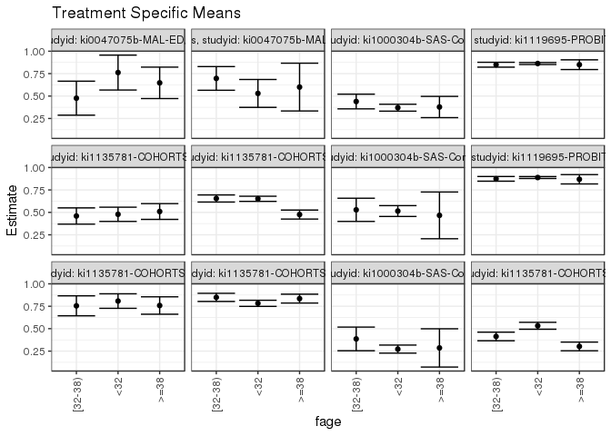

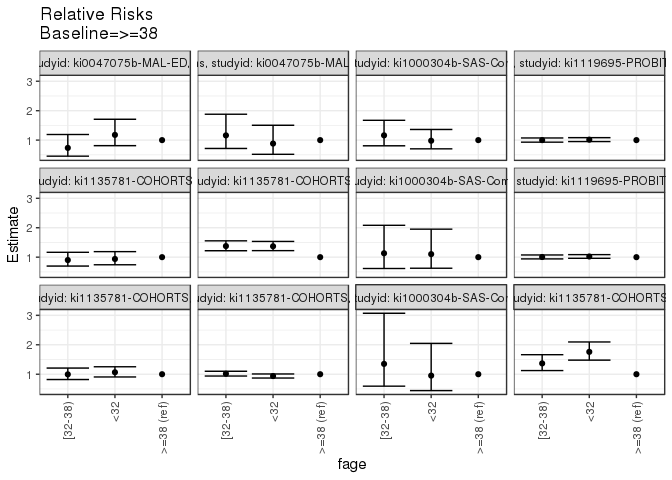

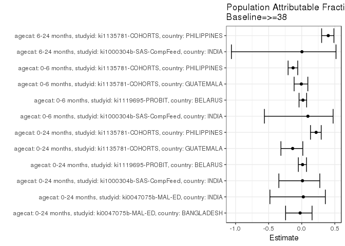

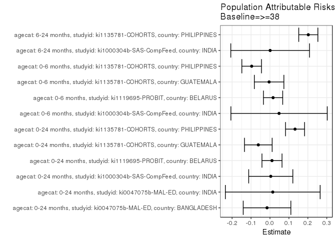

## Results Table

### Parameter: TSM

| agecat | studyid | country | intervention_level | baseline_level | estimate | ci_lower | ci_upper |
| --- | --- | --- | --- | --- | --- | --- | --- |
| 0-24 months | ki0047075b-MAL-ED | BANGLADESH | >=38 | NA | 0.6470588 | 0.4719757 | 0.8221420 |
| 0-24 months | ki0047075b-MAL-ED | BANGLADESH | <32 | NA | 0.7619048 | 0.5675039 | 0.9563056 |
| 0-24 months | ki0047075b-MAL-ED | BANGLADESH | [32-38) | NA | 0.4761905 | 0.2868777 | 0.6655032 |
| 0-24 months | ki0047075b-MAL-ED | INDIA | >=38 | NA | 0.6000000 | 0.3336484 | 0.8663516 |
| 0-24 months | ki0047075b-MAL-ED | INDIA | <32 | NA | 0.5294118 | 0.3739682 | 0.6848553 |
| 0-24 months | ki0047075b-MAL-ED | INDIA | [32-38) | NA | 0.6964286 | 0.5644321 | 0.8284250 |
| 0-24 months | ki1000304b-SAS-CompFeed | INDIA | >=38 | NA | 0.3780403 | 0.2595277 | 0.4965529 |
| 0-24 months | ki1000304b-SAS-CompFeed | INDIA | <32 | NA | 0.3701821 | 0.3317277 | 0.4086365 |
| 0-24 months | ki1000304b-SAS-CompFeed | INDIA | [32-38) | NA | 0.4392459 | 0.3573411 | 0.5211507 |
| 0-24 months | ki1119695-PROBIT | BELARUS | >=38 | NA | 0.8494338 | 0.7952411 | 0.9036265 |
| 0-24 months | ki1119695-PROBIT | BELARUS | <32 | NA | 0.8625159 | 0.8511840 | 0.8738477 |
| 0-24 months | ki1119695-PROBIT | BELARUS | [32-38) | NA | 0.8492696 | 0.8220069 | 0.8765322 |
| 0-24 months | ki1135781-COHORTS | GUATEMALA | >=38 | NA | 0.5095961 | 0.4218226 | 0.5973696 |
| 0-24 months | ki1135781-COHORTS | GUATEMALA | <32 | NA | 0.4782854 | 0.3989179 | 0.5576530 |
| 0-24 months | ki1135781-COHORTS | GUATEMALA | [32-38) | NA | 0.4594957 | 0.3689617 | 0.5500297 |
| 0-24 months | ki1135781-COHORTS | PHILIPPINES | >=38 | NA | 0.4756606 | 0.4255994 | 0.5257217 |
| 0-24 months | ki1135781-COHORTS | PHILIPPINES | <32 | NA | 0.6511913 | 0.6223531 | 0.6800294 |
| 0-24 months | ki1135781-COHORTS | PHILIPPINES | [32-38) | NA | 0.6547416 | 0.6151060 | 0.6943773 |
| 0-6 months | ki1000304b-SAS-CompFeed | INDIA | >=38 | NA | 0.4666667 | 0.2061538 | 0.7271796 |
| 0-6 months | ki1000304b-SAS-CompFeed | INDIA | <32 | NA | 0.5147059 | 0.4543062 | 0.5751055 |
| 0-6 months | ki1000304b-SAS-CompFeed | INDIA | [32-38) | NA | 0.5283019 | 0.3989989 | 0.6576049 |
| 0-6 months | ki1119695-PROBIT | BELARUS | >=38 | NA | 0.8688552 | 0.8168291 | 0.9208814 |
| 0-6 months | ki1119695-PROBIT | BELARUS | <32 | NA | 0.8882093 | 0.8774482 | 0.8989704 |
| 0-6 months | ki1119695-PROBIT | BELARUS | [32-38) | NA | 0.8736931 | 0.8475462 | 0.8998400 |
| 0-6 months | ki1135781-COHORTS | GUATEMALA | >=38 | NA | 0.7581888 | 0.6611094 | 0.8552681 |
| 0-6 months | ki1135781-COHORTS | GUATEMALA | <32 | NA | 0.8078975 | 0.7269364 | 0.8888586 |
| 0-6 months | ki1135781-COHORTS | GUATEMALA | [32-38) | NA | 0.7546441 | 0.6435358 | 0.8657525 |
| 0-6 months | ki1135781-COHORTS | PHILIPPINES | >=38 | NA | 0.8351422 | 0.7858721 | 0.8844124 |
| 0-6 months | ki1135781-COHORTS | PHILIPPINES | <32 | NA | 0.7826390 | 0.7486397 | 0.8166383 |
| 0-6 months | ki1135781-COHORTS | PHILIPPINES | [32-38) | NA | 0.8488662 | 0.8035493 | 0.8941831 |
| 6-24 months | ki1000304b-SAS-CompFeed | INDIA | >=38 | NA | 0.2857143 | 0.0723858 | 0.4990428 |
| 6-24 months | ki1000304b-SAS-CompFeed | INDIA | <32 | NA | 0.2722646 | 0.2273817 | 0.3171476 |
| 6-24 months | ki1000304b-SAS-CompFeed | INDIA | [32-38) | NA | 0.3859649 | 0.2542449 | 0.5176849 |
| 6-24 months | ki1135781-COHORTS | PHILIPPINES | >=38 | NA | 0.3024776 | 0.2541024 | 0.3508528 |
| 6-24 months | ki1135781-COHORTS | PHILIPPINES | <32 | NA | 0.5323433 | 0.4937784 | 0.5709082 |
| 6-24 months | ki1135781-COHORTS | PHILIPPINES | [32-38) | NA | 0.4135688 | 0.3656680 | 0.4614695 |

### Parameter: E(Y)

| agecat | studyid | country | intervention_level | baseline_level | estimate | ci_lower | ci_upper |
| --- | --- | --- | --- | --- | --- | --- | --- |
| 0-24 months | ki0047075b-MAL-ED | BANGLADESH | NA | NA | 0.6315789 | 0.5193816 | 0.7437763 |
| 0-24 months | ki0047075b-MAL-ED | INDIA | NA | NA | 0.6147541 | 0.5199078 | 0.7096004 |
| 0-24 months | ki1000304b-SAS-CompFeed | INDIA | NA | NA | 0.3822441 | 0.3470990 | 0.4173892 |
| 0-24 months | ki1119695-PROBIT | BELARUS | NA | NA | 0.8600988 | 0.8497563 | 0.8704412 |
| 0-24 months | ki1135781-COHORTS | GUATEMALA | NA | NA | 0.4480874 | 0.3954108 | 0.5007641 |
| 0-24 months | ki1135781-COHORTS | PHILIPPINES | NA | NA | 0.6080247 | 0.5830213 | 0.6330281 |
| 0-6 months | ki1000304b-SAS-CompFeed | INDIA | NA | NA | 0.5147059 | 0.4610948 | 0.5683169 |
| 0-6 months | ki1119695-PROBIT | BELARUS | NA | NA | 0.8852740 | 0.8754291 | 0.8951189 |
| 0-6 months | ki1135781-COHORTS | GUATEMALA | NA | NA | 0.7536232 | 0.6949302 | 0.8123162 |
| 0-6 months | ki1135781-COHORTS | PHILIPPINES | NA | NA | 0.7384615 | 0.7062339 | 0.7706892 |
| 6-24 months | ki1000304b-SAS-CompFeed | INDIA | NA | NA | 0.2866242 | 0.2446853 | 0.3285631 |
| 6-24 months | ki1135781-COHORTS | PHILIPPINES | NA | NA | 0.5049724 | 0.4705318 | 0.5394130 |

### Parameter: RR

| agecat | studyid | country | intervention_level | baseline_level | estimate | ci_lower | ci_upper |
| --- | --- | --- | --- | --- | --- | --- | --- |
| 0-24 months | ki0047075b-MAL-ED | BANGLADESH | >=38 | >=38 | 1.0000000 | 1.0000000 | 1.000000 |
| 0-24 months | ki0047075b-MAL-ED | BANGLADESH | <32 | >=38 | 1.1774892 | 0.8118096 | 1.707889 |
| 0-24 months | ki0047075b-MAL-ED | BANGLADESH | [32-38) | >=38 | 0.7359307 | 0.4549883 | 1.190347 |
| 0-24 months | ki0047075b-MAL-ED | INDIA | >=38 | >=38 | 1.0000000 | 1.0000000 | 1.000000 |
| 0-24 months | ki0047075b-MAL-ED | INDIA | <32 | >=38 | 0.8823529 | 0.5176350 | 1.504046 |
| 0-24 months | ki0047075b-MAL-ED | INDIA | [32-38) | >=38 | 1.1607143 | 0.7166205 | 1.880016 |
| 0-24 months | ki1000304b-SAS-CompFeed | INDIA | >=38 | >=38 | 1.0000000 | 1.0000000 | 1.000000 |
| 0-24 months | ki1000304b-SAS-CompFeed | INDIA | <32 | >=38 | 0.9792133 | 0.7041061 | 1.361810 |
| 0-24 months | ki1000304b-SAS-CompFeed | INDIA | [32-38) | >=38 | 1.1619023 | 0.8071781 | 1.672514 |
| 0-24 months | ki1119695-PROBIT | BELARUS | >=38 | >=38 | 1.0000000 | 1.0000000 | 1.000000 |
| 0-24 months | ki1119695-PROBIT | BELARUS | <32 | >=38 | 1.0154009 | 0.9514387 | 1.083663 |
| 0-24 months | ki1119695-PROBIT | BELARUS | [32-38) | >=38 | 0.9998067 | 0.9309699 | 1.073733 |
| 0-24 months | ki1135781-COHORTS | GUATEMALA | >=38 | >=38 | 1.0000000 | 1.0000000 | 1.000000 |
| 0-24 months | ki1135781-COHORTS | GUATEMALA | <32 | >=38 | 0.9385579 | 0.7417289 | 1.187618 |
| 0-24 months | ki1135781-COHORTS | GUATEMALA | [32-38) | >=38 | 0.9016862 | 0.6977183 | 1.165281 |
| 0-24 months | ki1135781-COHORTS | PHILIPPINES | >=38 | >=38 | 1.0000000 | 1.0000000 | 1.000000 |
| 0-24 months | ki1135781-COHORTS | PHILIPPINES | <32 | >=38 | 1.3690252 | 1.2218837 | 1.533886 |
| 0-24 months | ki1135781-COHORTS | PHILIPPINES | [32-38) | >=38 | 1.3764892 | 1.2189492 | 1.554390 |
| 0-6 months | ki1000304b-SAS-CompFeed | INDIA | >=38 | >=38 | 1.0000000 | 1.0000000 | 1.000000 |
| 0-6 months | ki1000304b-SAS-CompFeed | INDIA | <32 | >=38 | 1.1029412 | 0.6234654 | 1.951158 |
| 0-6 months | ki1000304b-SAS-CompFeed | INDIA | [32-38) | >=38 | 1.1320755 | 0.6153979 | 2.082547 |
| 0-6 months | ki1119695-PROBIT | BELARUS | >=38 | >=38 | 1.0000000 | 1.0000000 | 1.000000 |
| 0-6 months | ki1119695-PROBIT | BELARUS | <32 | >=38 | 1.0222753 | 0.9617447 | 1.086616 |
| 0-6 months | ki1119695-PROBIT | BELARUS | [32-38) | >=38 | 1.0055681 | 0.9405178 | 1.075117 |
| 0-6 months | ki1135781-COHORTS | GUATEMALA | >=38 | >=38 | 1.0000000 | 1.0000000 | 1.000000 |
| 0-6 months | ki1135781-COHORTS | GUATEMALA | <32 | >=38 | 1.0655624 | 0.9063997 | 1.252674 |
| 0-6 months | ki1135781-COHORTS | GUATEMALA | [32-38) | >=38 | 0.9953249 | 0.8196262 | 1.208687 |
| 0-6 months | ki1135781-COHORTS | PHILIPPINES | >=38 | >=38 | 1.0000000 | 1.0000000 | 1.000000 |
| 0-6 months | ki1135781-COHORTS | PHILIPPINES | <32 | >=38 | 0.9371326 | 0.8706527 | 1.008689 |
| 0-6 months | ki1135781-COHORTS | PHILIPPINES | [32-38) | >=38 | 1.0164331 | 0.9389791 | 1.100276 |
| 6-24 months | ki1000304b-SAS-CompFeed | INDIA | >=38 | >=38 | 1.0000000 | 1.0000000 | 1.000000 |
| 6-24 months | ki1000304b-SAS-CompFeed | INDIA | <32 | >=38 | 0.9529262 | 0.4435900 | 2.047089 |
| 6-24 months | ki1000304b-SAS-CompFeed | INDIA | [32-38) | >=38 | 1.3508772 | 0.5944071 | 3.070066 |
| 6-24 months | ki1135781-COHORTS | PHILIPPINES | >=38 | >=38 | 1.0000000 | 1.0000000 | 1.000000 |
| 6-24 months | ki1135781-COHORTS | PHILIPPINES | <32 | >=38 | 1.7599429 | 1.4781637 | 2.095437 |
| 6-24 months | ki1135781-COHORTS | PHILIPPINES | [32-38) | >=38 | 1.3672707 | 1.1239211 | 1.663310 |

### Parameter: PAR

| agecat | studyid | country | intervention_level | baseline_level | estimate | ci_lower | ci_upper |
| --- | --- | --- | --- | --- | --- | --- | --- |
| 0-24 months | ki0047075b-MAL-ED | BANGLADESH | >=38 | NA | -0.0154799 | -0.1412234 | 0.1102637 |
| 0-24 months | ki0047075b-MAL-ED | INDIA | >=38 | NA | 0.0147541 | -0.2355840 | 0.2650922 |
| 0-24 months | ki1000304b-SAS-CompFeed | INDIA | >=38 | NA | 0.0042038 | -0.1123048 | 0.1207125 |
| 0-24 months | ki1119695-PROBIT | BELARUS | >=38 | NA | 0.0106650 | -0.0423071 | 0.0636371 |
| 0-24 months | ki1135781-COHORTS | GUATEMALA | >=38 | NA | -0.0615086 | -0.1346241 | 0.0116068 |
| 0-24 months | ki1135781-COHORTS | PHILIPPINES | >=38 | NA | 0.1323641 | 0.0820787 | 0.1826496 |
| 0-6 months | ki1000304b-SAS-CompFeed | INDIA | >=38 | NA | 0.0480392 | -0.2064266 | 0.3025050 |
| 0-6 months | ki1119695-PROBIT | BELARUS | >=38 | NA | 0.0164187 | -0.0344348 | 0.0672723 |
| 0-6 months | ki1135781-COHORTS | GUATEMALA | >=38 | NA | -0.0045656 | -0.0825412 | 0.0734100 |
| 0-6 months | ki1135781-COHORTS | PHILIPPINES | >=38 | NA | -0.0966807 | -0.1486065 | -0.0447549 |
| 6-24 months | ki1000304b-SAS-CompFeed | INDIA | >=38 | NA | 0.0009099 | -0.2069616 | 0.2087814 |
| 6-24 months | ki1135781-COHORTS | PHILIPPINES | >=38 | NA | 0.2024948 | 0.1520048 | 0.2529847 |

### Parameter: PAF

| agecat | studyid | country | intervention_level | baseline_level | estimate | ci_lower | ci_upper |
| --- | --- | --- | --- | --- | --- | --- | --- |
| 0-24 months | ki0047075b-MAL-ED | BANGLADESH | >=38 | NA | -0.0245098 | -0.2439004 | 0.1561862 |
| 0-24 months | ki0047075b-MAL-ED | INDIA | >=38 | NA | 0.0240000 | -0.4812659 | 0.3569176 |
| 0-24 months | ki1000304b-SAS-CompFeed | INDIA | >=38 | NA | 0.0109978 | -0.3458673 | 0.2732379 |
| 0-24 months | ki1119695-PROBIT | BELARUS | >=38 | NA | 0.0123997 | -0.0511533 | 0.0721102 |
| 0-24 months | ki1135781-COHORTS | GUATEMALA | >=38 | NA | -0.1372693 | -0.3146478 | 0.0161765 |
| 0-24 months | ki1135781-COHORTS | PHILIPPINES | >=38 | NA | 0.2176953 | 0.1325074 | 0.2945178 |
| 0-6 months | ki1000304b-SAS-CompFeed | INDIA | >=38 | NA | 0.0933333 | -0.5644012 | 0.4745309 |
| 0-6 months | ki1119695-PROBIT | BELARUS | >=38 | NA | 0.0185465 | -0.0406173 | 0.0743465 |
| 0-6 months | ki1135781-COHORTS | GUATEMALA | >=38 | NA | -0.0060582 | -0.1150405 | 0.0922724 |
| 0-6 months | ki1135781-COHORTS | PHILIPPINES | >=38 | NA | -0.1309218 | -0.2060505 | -0.0604731 |
| 6-24 months | ki1000304b-SAS-CompFeed | INDIA | >=38 | NA | 0.0031746 | -1.0634622 | 0.5184497 |
| 6-24 months | ki1135781-COHORTS | PHILIPPINES | >=38 | NA | 0.4010017 | 0.3010104 | 0.4866891 |